# 2019-10-05: BDS 100m Präzision ZF – 100m – DAR15 - Zielfernrohr

## Überblick – Schussgruppen

### Unveränderte Schussgruppen

|  | Shots | Rings | Max | Mean | Median | BDS9-Tenth | Sigma (mm) | Dist POA (mm) | Circle (mm) |
| --- | --- | --- | --- | --- | --- | --- | --- | --- | --- |
| **1. Group** | 15 | 136 | 150 | 9.1 | 9 | 10.0 | 22 | 15.0 | 72 |
| **2. Group** | 13 | 113 | 130 | 8.7 | 9 | 9.7 | 21 | 29.4 | 82 |
| **All Shots** | 28 | 249 | 280 | 8.9 | 9 | 9.9 | 20 | 21.0 | 82 |
| **20 Shots** | 20 | 178 | 200 | 8.9 | 9 | 9.9 | 20 | 21.0 | 82 |
| **30 Shots** | 30 | 267 | 300 | 8.9 | 9 | 9.9 | 20 | 21.0 | 82 |
| **40 Shots** | 40 | 356 | 400 | 8.9 | 9 | 9.9 | 20 | 21.0 | 82 |

### Nach angenommener, optimaler Visier-Korrektur

Im Abschnitt *Visiereinstellungen* wird eine Visiereinstellung berechnet, die zum bestmöglichen Ergebnis führen würde. Nach den vorgeschlagenen Korrekturen würde das Ergebnis wie folgt aussehen:

|  | Shots | Rings | Max | Mean | Median | BDS9-Tenth | Sigma (mm) | Dist POA (mm) | Circle (mm) |
| --- | --- | --- | --- | --- | --- | --- | --- | --- | --- |
| **1. Group** | 15 | 139 | 150 | 9.3 | 9 | 10.1 | 22 | 5.2 | 72 |
| **2. Group** | 13 | 121 | 130 | 9.3 | 10 | 10.1 | 21 | 9.7 | 82 |
| **All Shots** | 28 | 260 | 280 | 9.3 | 9 | 10.1 | 20 | 1.2 | 82 |
| **20 Shots** | 20 | 186 | 200 | 9.3 | 9 | 10.1 | 20 | 1.2 | 82 |
| **30 Shots** | 30 | 279 | 300 | 9.3 | 9 | 10.1 | 20 | 1.2 | 82 |
| **40 Shots** | 40 | 371 | 400 | 9.3 | 9 | 10.1 | 20 | 1.2 | 82 |

### Erläuterungen

- *Hits* sind die Anzahl der Treffer einer Schussgruppe. Schüsse die außerhalb der Scheibe liegen, können naturgemäß nicht dargestellt werden.
- *Rings* ist das erreichte Schießergebnis und
- *Max Rings* das maximal mögliche Ergebnis.
- *Mean* Ist durch ist das durchschnittliche Ergebnis eines Ringes und
- *Median* der typische, also am häufigsten getroffene, Ring.
- *BDS9-Tenth* Durchschnittliche Ringe pro Schuss bei Zehntelwertung auf einer BDS9-Scheibe. Die Berechnung der Zehntel erfolgt unabhängig vom Scheibentyp immer auf der BDS9-Scheibe für Kurzwaffen.
- *Sigma* gibt den Radius des Kreises an, der mit einer 39%igen Wahrscheinlichkeit getroffen wird. Aus *Sigma* lässt sich die Wahrscheinlichkeit eines Treffers für eine bestimmte Entfernung berechnen. Damit ist *Sigma* ein Wert für die Dichte der Schussgruppe und eine zentrale Kenngröße der Schusspräzision. Auf [http://ballistipedia.com](http://ballistipedia.com/index.php?title=Closed_Form_Precision) gibt es weitere Erklärungen.
- *Dist POA* ist der Abstand zum Scheibenmittelpunkt, dem Point Of Aim, und damit ein Maß für die Präzision.
- *Circle* ist der Durchmesser eines Kreises, welche die Schussgruppe vollständig umschließt. *Circle* ist ein gebräuchlicher und einfach zu ermittelndes Maß der Genauigkeit. Da *Circle* nicht die Dichte der Schussgruppe berücksichtigt, ist dieses Maß für die Ermittlung von Trefferwahrscheinlichkeiten irrelevant.

### Visiereinstellungen

|  | x (horizontal) | y (vertical) |
| --- | --- | --- |
| Distance to Group Center in mm | -21 | 0.7 |
| Sight Correction in Clicks | 2 | 0.0 |
| Distance after Correction in mm | -1 | 0.7 |

Die statistische Signifikanz, also die Aussagekräftigkeit, der zugrundeliegenden Berechnungen ist *very high*. Bei der Berechnung der Visiereinstellung wurde ein gegen Ausreisser robuster Algorithmus benutzt.

Eine Korrektur der Visiereinstellungen sollte nur vorgenommen werden, wenn die Signifikanz *high* or *very high* ist. Neben einer falschen Visiereinstellungen können ungenaue Schüsse durch die Schussballistik, Witterungseinflüsse oder Schützenfehler entstehen.

- Median X: -17.823
  - Standardabweichung X: 20.1475449
  - Standardfehler X: 3.8075281
  - Fehlerzahl X: 0
  - Median Y: -4.5655
  - Standardabweichung Y: 18.0021465
  - Standardfehler Y: 3.4020859
  - Fehlerzahl Y: 4

### Trefferwahrscheinlichkeit

[figure not shown]

### Trefferdarstellung auf einer BDS1 Scheibe

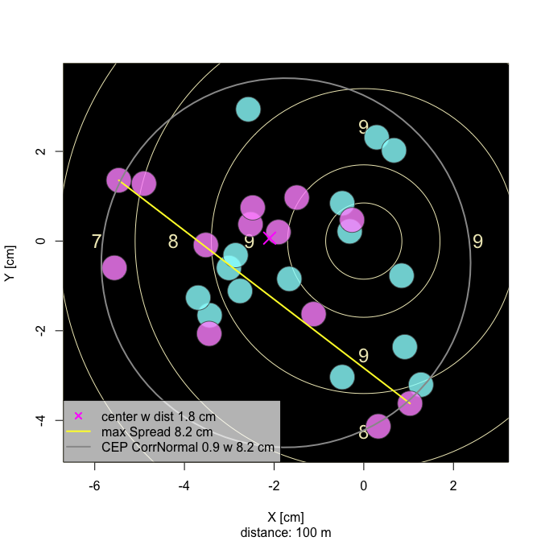

Die Darstellung erfolgte für alle Schussgruppen im Kaliber 5.56 mm auf einer Entfernung von 100 m.

Geschossen wurden *8* 10er, *11* 9er. Es gab *9* Fehlschüsse. Umgerechnet auf 20 Schuss sind das *6* 10er, *8* 9er und *6* Fehlschüsse.

### Datenquelle

Der Report wurde am 2019-10-05 aus dem Point Data File *OnTargetPt.csv* erstellt.